# Lab 1 - Gapminder Dataset Visualization

Author

Austin Liu

```python
#Libraries and Packages
import pandas as pd

from plotnine import *
```

## Task 1: Income vs. Life Expectancy

1. Aesthetics being used: x = income, y = life expectancy, color = Four regions of the world, size = population, text on the plot

```python
#2. Data Import
df = pd.read_csv("/Users/AustinLiu/Desktop/GSB544-ComputingandMachineLearning/Lab_Data/q1data.csv")
df = df.dropna()
df
```

|  | income | life_exp | population | year | country | four_regions | six_regions | eight_regions | world_bank_region |
| --- | --- | --- | --- | --- | --- | --- | --- | --- | --- |
| 0 | 1910.0 | 61.0 | 29200000.0 | 2010 | Afghanistan | asia | south_asia | asia_west | South Asia |
| 1 | 11100.0 | 78.1 | 2950000.0 | 2010 | Albania | europe | europe_central_asia | europe_east | Europe & Central Asia |
| 2 | 11100.0 | 74.7 | 36000000.0 | 2010 | Algeria | africa | middle_east_north_africa | africa_north | Middle East & North Africa |
| 3 | 46900.0 | 81.9 | 84500.0 | 2010 | Andorra | europe | europe_central_asia | europe_west | Europe & Central Asia |
| 4 | 7680.0 | 60.8 | 23400000.0 | 2010 | Angola | africa | sub_saharan_africa | africa_sub_saharan | Sub-Saharan Africa |
| ... | ... | ... | ... | ... | ... | ... | ... | ... | ... |
| 192 | 20400.0 | 75.4 | 28400000.0 | 2010 | Venezuela | americas | america | america_south | Latin America & Caribbean |
| 193 | 5350.0 | 73.3 | 88000000.0 | 2010 | Vietnam | asia | east_asia_pacific | east_asia_pacific | East Asia & Pacific |
| 194 | 4700.0 | 67.8 | 23200000.0 | 2010 | Yemen | asia | middle_east_north_africa | asia_west | Middle East & North Africa |
| 195 | 3200.0 | 57.5 | 13600000.0 | 2010 | Zambia | africa | sub_saharan_africa | africa_sub_saharan | Sub-Saharan Africa |
| 196 | 2560.0 | 54.4 | 12700000.0 | 2010 | Zimbabwe | africa | sub_saharan_africa | africa_sub_saharan | Sub-Saharan Africa |

191 rows × 9 columns

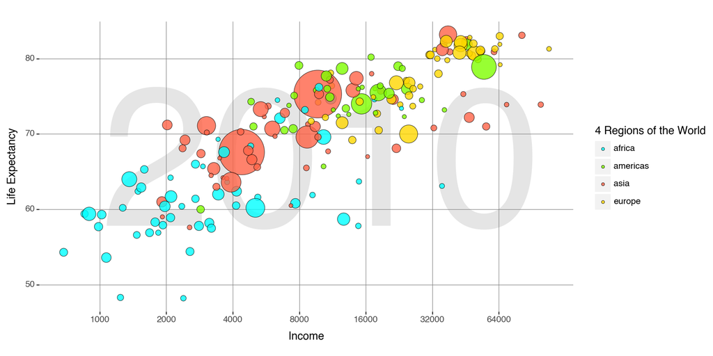

```
<Figure Size: (1000 x 500)>
```

```python
#3.

(ggplot(df,
        aes(x = "income", y = "life_exp", fill = "four_regions", size = "population"))
 + annotate('text', x = 10000, y = 64.5, label = '2010', color = 'gray', size = 200, alpha = 0.2)
 + geom_point(alpha = 0.8, stroke = 0.25)
 + scale_size(range = [2, 27])
 + guides(size = False)
 + scale_y_continuous(breaks = [0, 20, 30, 40, 50, 60, 70, 80, 90])
 + scale_x_continuous(breaks = [0, 500, 1000, 2000, 4000, 8000, 16000, 32000, 64000],
                      trans = "log10")
 + theme(figure_size = (10,5),
         panel_background = element_rect(fill = 'white'),
         panel_grid = element_line(color = 'gray', size = 0.5, linetype = 'solid'),
         panel_grid_minor = element_blank())
 + labs(x = "Income", y = "Life Expectancy", fill = "4 Regions of the World")
 + scale_fill_manual(values = ["cyan", "chartreuse", "tomato", "gold"]))
```

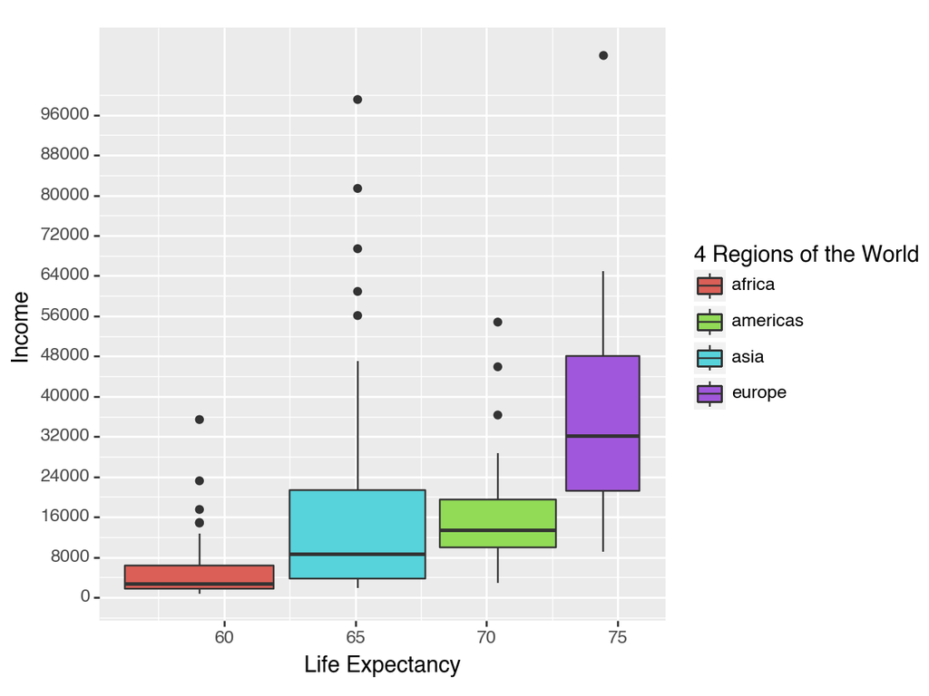

```
<Figure Size: (640 x 480)>
```

```python
#4.

(ggplot(df, aes(y = "income", x = "life_exp", fill = "four_regions"))
 + geom_boxplot()
 + scale_y_continuous(breaks = [0, 8000, 16000, 24000, 32000, 40000, 48000, 56000, 64000,
                               72000, 80000, 88000, 96000])
 + labs(y = "Income", x = "Life Expectancy", fill = "4 Regions of the World"))
```

Geom boxplot is a geometry that is good for comparing the distributions between groups. This geometry is strong because it conveys a similar message to the scatterplot. In general, life expectancy increase is correlated to an increase in Income. However, this geometry cannot accomodate a 4th variable for visualization without becoming too distracting.

## Task 2: Exports vs. Imports

1. Aesthetics being used: x = exports, y = imports, color = Four regions of the world, size = energy usage, text on the plot

```python
#2. Data Import
df2 = pd.read_csv("/Users/AustinLiu/Desktop/GSB544-ComputingandMachineLearning/Lab_Data/q2data.csv")
df2 = df2.dropna()
df2
```

|  | imports | exports | energy | year | country | four_regions | six_regions | eight_regions | world_bank_region |
| --- | --- | --- | --- | --- | --- | --- | --- | --- | --- |
| 1 | 36.7 | 11.5 | 427.0 | 1997 | Albania | europe | europe_central_asia | europe_east | Europe & Central Asia |
| 2 | 22.5 | 22.6 | 825.0 | 1997 | Algeria | africa | middle_east_north_africa | africa_north | Middle East & North Africa |
| 6 | 12.9 | 10.4 | 1660.0 | 1997 | Argentina | americas | america | america_south | Latin America & Caribbean |
| 7 | 52.8 | 19.0 | 610.0 | 1997 | Armenia | europe | europe_central_asia | europe_east | Europe & Central Asia |
| 9 | 20.5 | 19.6 | 5550.0 | 1997 | Australia | asia | east_asia_pacific | east_asia_pacific | East Asia & Pacific |
| ... | ... | ... | ... | ... | ... | ... | ... | ... | ... |
| 198 | 22.9 | 22.6 | 2080.0 | 1997 | Uzbekistan | asia | europe_central_asia | asia_west | Europe & Central Asia |
| 200 | 22.7 | 20.9 | 2250.0 | 1997 | Venezuela | americas | america | america_south | Latin America & Caribbean |
| 201 | 52.2 | 44.8 | 340.0 | 1997 | Vietnam | asia | east_asia_pacific | east_asia_pacific | East Asia & Pacific |
| 204 | 31.6 | 24.6 | 617.0 | 1997 | Zambia | africa | sub_saharan_africa | africa_sub_saharan | Sub-Saharan Africa |
| 205 | 45.1 | 43.4 | 845.0 | 1997 | Zimbabwe | africa | sub_saharan_africa | africa_sub_saharan | Sub-Saharan Africa |

127 rows × 9 columns

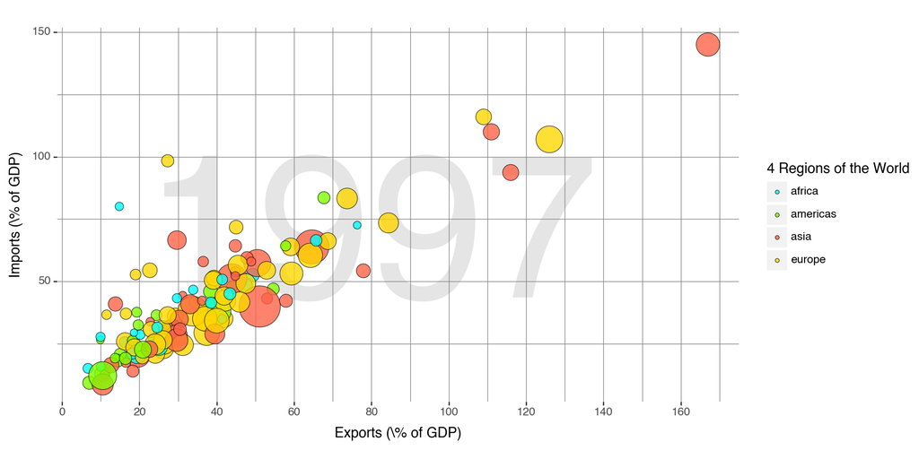

```
<Figure Size: (1000 x 500)>
```

```python
#3.

(ggplot(df2,
        aes(x = "exports", y = "imports", fill = "four_regions", size = "energy"))
 + annotate('text', x = 80, y = 64.5, label = '1997', color = 'gray', size = 160, alpha = 0.2)
 + geom_point(alpha = 0.8, stroke = 0.25)
 + guides(size = False)
 + scale_size(range = [2, 18])
 + scale_x_continuous(breaks = [0, 20, 40, 60, 80, 100, 120, 140, 160, 180, 200])
 + scale_y_continuous(breaks = [0, 50, 100, 150, 200, 250, 300, 350, 400])
 + theme(figure_size = (10,5), panel_background = element_rect(fill = 'white'),
         panel_grid = element_line(color = 'gray', size = 0.5, linetype = 'solid'))
 + labs(x = "Exports (\% of GDP)", y = "Imports (\% of GDP)", fill = "4 Regions of the World")
 + scale_fill_manual(values = ["cyan", "chartreuse", "tomato", "gold"]))
```

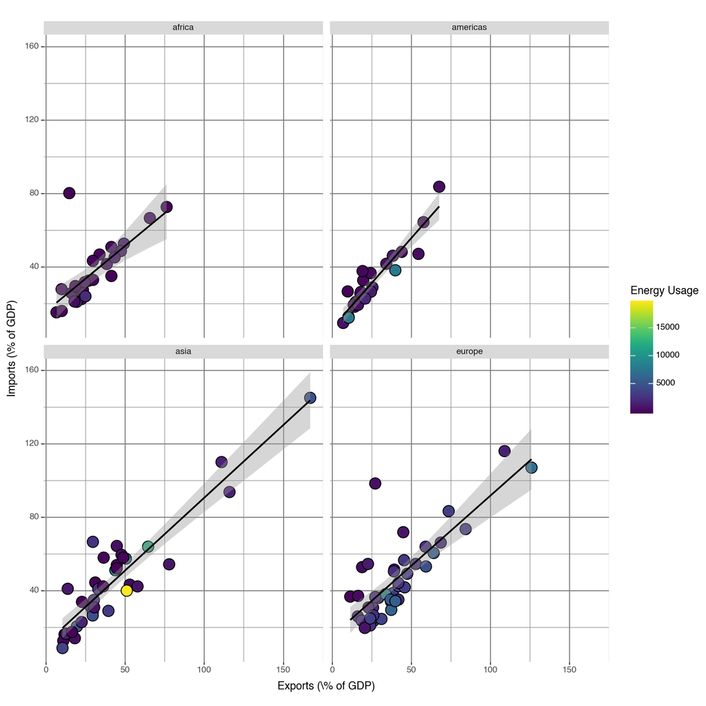

```
<Figure Size: (1000 x 1000)>
```

```python
#4.

(ggplot(df2,
        aes(x = "exports", y = "imports", fill = "energy", size = 3))
 + geom_jitter()
 + geom_smooth(method = 'lm', color='black', size = 1)
 + guides(size = False)
 + theme(figure_size = (10,10), panel_background = element_rect(fill = 'white'),
         panel_grid = element_line(color = 'gray', linetype = 'solid'))
 + labs(x = "Exports (\% of GDP)", y = "Imports (\% of GDP)", fill = "Energy Usage")
 + facet_wrap("four_regions"))
```

Geom Jitter is almost the same as geom point but reduces overlap of points compared to geom point. Geom smooth is a geometry that can be used to plot the line of best fit. I believe this is a good geometry because of how much overlap we have and it is interesting to see the least squares regression between the 2 variables. It is difficult to accomodate all 4 variables as the energy scale fill color makes it difficult to discern.

## Task 3: Individuals using internet vs. GDP per Capita

1. Aesthetics being used: x = internet usage, y = GDP/Capita, color = Four regions of the world, size = income, text on the plot

```python
#2. Data Import
df3 = pd.read_csv("/Users/AustinLiu/Desktop/GSB544-ComputingandMachineLearning/Lab_Data/q3data.csv")
df3 = df3.dropna()
df3
```

|  | internet_users | gdp | income | year | country | four_regions | six_regions | eight_regions | world_bank_region |
| --- | --- | --- | --- | --- | --- | --- | --- | --- | --- |
| 0 | 0.00456 | 330.0 | 1190.0 | 2001 | Afghanistan | asia | south_asia | asia_west | South Asia |
| 1 | 0.39000 | 2570.0 | 6780.0 | 2001 | Albania | europe | europe_central_asia | europe_east | Europe & Central Asia |
| 2 | 1.59000 | 3770.0 | 9230.0 | 2001 | Algeria | africa | middle_east_north_africa | africa_north | Middle East & North Africa |
| 4 | 11.30000 | 42600.0 | 35600.0 | 2001 | Andorra | europe | europe_central_asia | europe_west | Europe & Central Asia |
| 5 | 0.27000 | 2440.0 | 2900.0 | 2001 | Angola | africa | sub_saharan_africa | africa_sub_saharan | Sub-Saharan Africa |
| ... | ... | ... | ... | ... | ... | ... | ... | ... | ... |
| 209 | 4.91000 | 10800.0 | 14800.0 | 2001 | Venezuela | americas | america | america_south | Latin America & Caribbean |
| 210 | 1.85000 | 847.0 | 3270.0 | 2001 | Vietnam | asia | east_asia_pacific | east_asia_pacific | East Asia & Pacific |
| 212 | 0.51900 | 1190.0 | 4940.0 | 2001 | Yemen | asia | middle_east_north_africa | asia_west | Middle East & North Africa |
| 213 | 0.47800 | 991.0 | 2080.0 | 2001 | Zambia | africa | sub_saharan_africa | africa_sub_saharan | Sub-Saharan Africa |
| 214 | 1.10000 | 1330.0 | 3190.0 | 2001 | Zimbabwe | africa | sub_saharan_africa | africa_sub_saharan | Sub-Saharan Africa |

181 rows × 9 columns

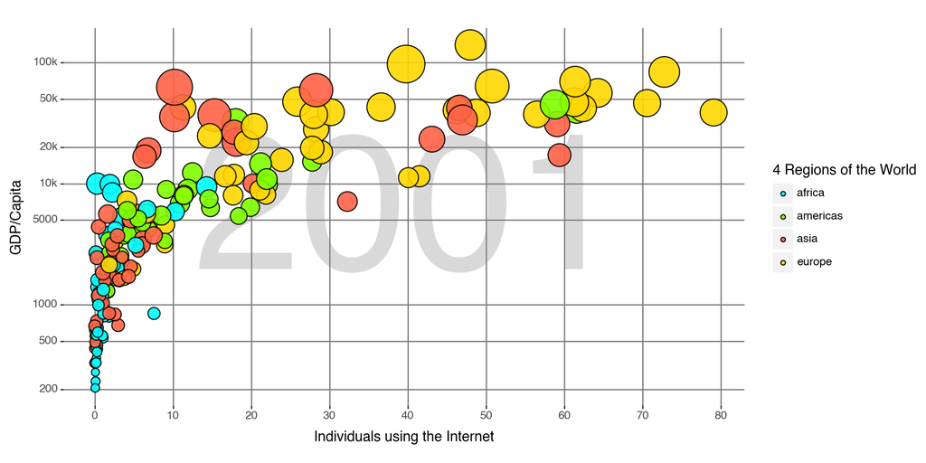

```
<Figure Size: (1000 x 500)>
```

```python
#3.

(ggplot(df3,
        aes(x = "internet_users", y = "gdp", fill = "four_regions", size = "income"))
 + annotate('text', x = 40, y = 5000, label = '2001', color = 'gray', size = 150, alpha = 0.3)
 + geom_point(alpha = 0.9)
 + scale_size(range = [3, 16])
 + guides(size = False)
 + scale_x_continuous(breaks = [0, 10, 20, 30, 40, 50, 60, 70, 80])
 + scale_y_continuous(breaks = [200, 500, 1000, 5000, 10000, 20000, 50000, 100000],
                      labels = ["200", "500", "1000", "5000", "10k", "20k", "50k", "100k"],
                      trans = "log10")
 + theme(figure_size = (10,5), panel_background = element_rect(fill = 'white'), panel_grid_minor = element_blank(),
         panel_grid = element_line(color = 'gray', linetype = 'solid'))
 + labs(x = "Individuals using the Internet", y = "GDP/Capita", fill = "4 Regions of the World")
 + scale_fill_manual(values = ["cyan", "chartreuse", "tomato", "gold"]))
```

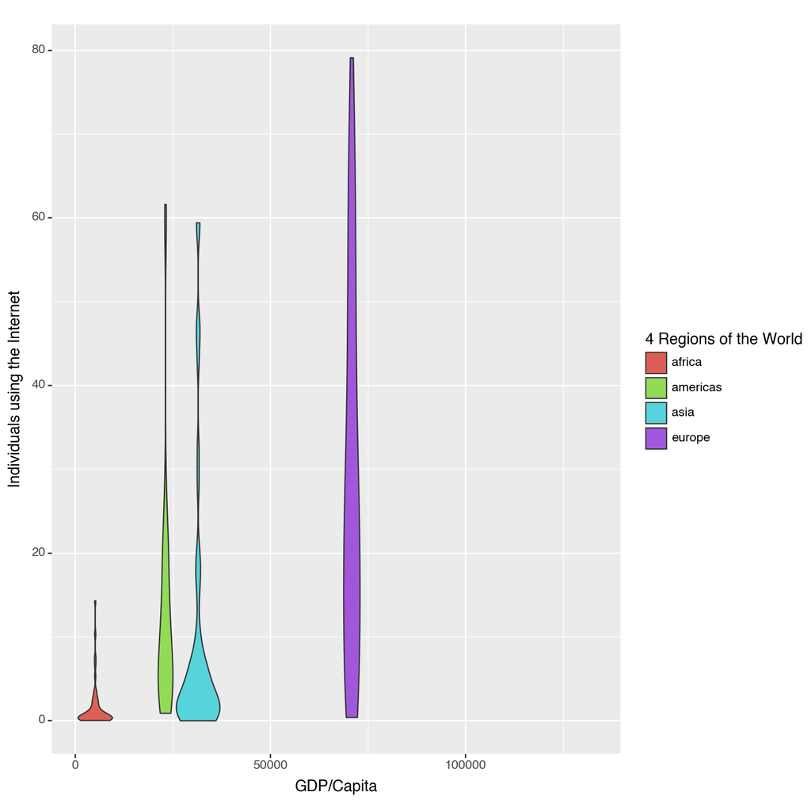

```
<Figure Size: (800 x 800)>
```

```python
#4.

(ggplot(df3, aes(x = "gdp", y = "internet_users", fill = "four_regions"))
 + geom_violin()
 + theme(figure_size = (8,8))
 + labs(y = "Individuals using the Internet", x = "GDP/Capita", fill = "4 Regions of the World"))
```

Geom violin shows a violin plot that is used to compare the distributions of the variables by region of the world. The violin plot is visual focused and shows the shape/spread. This geometry is good, but cannot be used to accomodate another variable like income without negatively affecting the focus of the visualization.